# Profile likelihood

Svenja

```r
library(dMod)
```

This calander door gives you a basic overview about how you can perform **profile likelihood** calculations with dMod and how you can display the resulting profiles. The procedure will be exemplified with the following ABC toymodel:

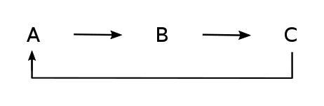

```r
### This Code defines the ABC toymodel ###

# Define reactions
reactions <- NULL
reactions <- addReaction(reactions, "A_state", "B_state",
                         rate = "k1*A_state",
                         description = "A to B")
reactions <- addReaction(reactions, "B_state", "C_state",
                         rate = "k2*B_state",
                         description = "B to C")
reactions <- addReaction(reactions, "C_state", "A_state",
                         rate = "k3*C_state",
                         description = "C to A")

# Translate into ODE model
ABC_model <- odemodel(reactions, modelname = "ABCmodel")
```

```
## A shared object with name ABCmodel already existed and was overwritten.
```

```
## A shared object with name ABCmodel_s already existed and was overwritten.
```

```r
# Generate prediction function from ODE model
x <- Xs(ABC_model, condition = NULL)

# Define observations
observables <- eqnvec(
  B_obs = "scale*B_state",
  C_obs = "scale*C_state")

# Generate observation function
g <- Y(observables, f = reactions, condition = NULL,
       compile = TRUE, modelname = "obsfn")
```

```
## A shared object with name obsfn already existed and was overwritten.
```

```
## A shared object with name obsfn_deriv already existed and was overwritten.
```

```r
# Simuate data
# Define time points for data simulation
timesD <- c(3, 11, 20, 35, 50) #c(0.1, 1, 3, 7, 11, 15, 20, 41)

# Define parameter values for data simulation
pars <- c(A_state = 0.93,
          B_state = 0.1,
          C_state = 0.1,
          k1 = 0.2,
          k2 = 0.072,
          k3 = 0.1,
          scale = 1e3)

# Generate a prediction
times <- seq(0, 50, .1)
out <- (g*x)(times, pars, conditions = "standard")

datasheet <- subset(wide2long(out), time %in% timesD & name %in% names(observables))
datasheet$sigma <- sqrt(datasheet$value + 1)
datasheet$value <- rnorm(nrow(datasheet), datasheet$value, datasheet$sigma)

data <- as.datalist(datasheet)

# Log-transform parameters for fitting
innerpars <- unique(c(getParameters(ABC_model), getParameters(g)))
trafo <- as.eqnvec(innerpars, names = innerpars)

p <- P(
  trafo <- repar("x ~ exp(x)", trafo, x = innerpars),
  condition = "standard")

outerpars <- getParameters(p)
parinit <- structure(rep(-1, length(outerpars)), names = outerpars)

# Generate objective function (to be optimized)
obj <- normL2(data, g*x*p) + constraintL2(parinit, sigma = 10)

### End model definition ###

# Perform a multi-start optimization
out_mstrust <- mstrust(obj, parinit, rinit = 1, rmax = 10, iterlim = 500,
                       cores = detectFreeCores(), fits = 10)

fitlist <- as.parframe(out_mstrust)
```

#### 1. **Calculate** the profile likelihood:

The profile likelihood can be computed with the function **profile()**. Depending on the size of your model it is recommendable to run the computation on an external machine.

```r
bestfit <- as.parvec(fitlist, 1)
whichPar <- names(bestfit)
myprofiles <- profile(obj, bestfit, whichPar,
                      limits = c(-5, 5), algoControl = list(reg = 0),
                      cores = min(length(whichPar),detectFreeCores()))
```

You have to define the parameter vector corresponding to the analyzed optimum, here *bestfit*, and a vector containing the parameters for which the profiles are computed, *whichPar*. To extend the analyzed parameter value range the maximal lower and the upper deviance from the original value can be adjusted in *limits*.

#### 2. **Plot** profiles:

Profiles can be easily visualized using **plotProfile()**. If a prior was defined in the objective function, the different contributions of prior and data can be seperately displayed defining the *mode*.

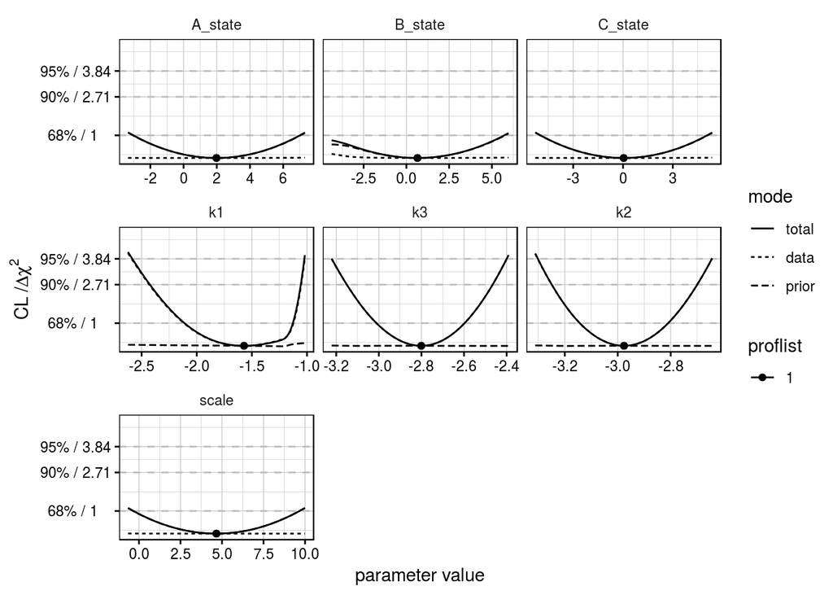

```r
plotProfile(myprofiles)
```

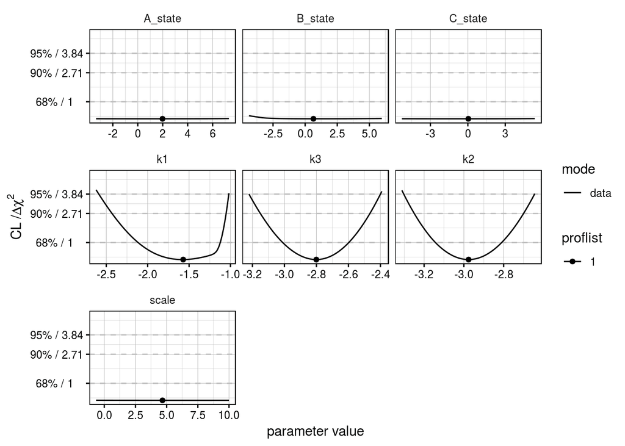

```r
plotProfile(myprofiles, mode == "data")
```

#### 3. Analyzing parameter dependencies:

**Parameter dependecies** can be displayed by profile paths using **plotPaths()**.

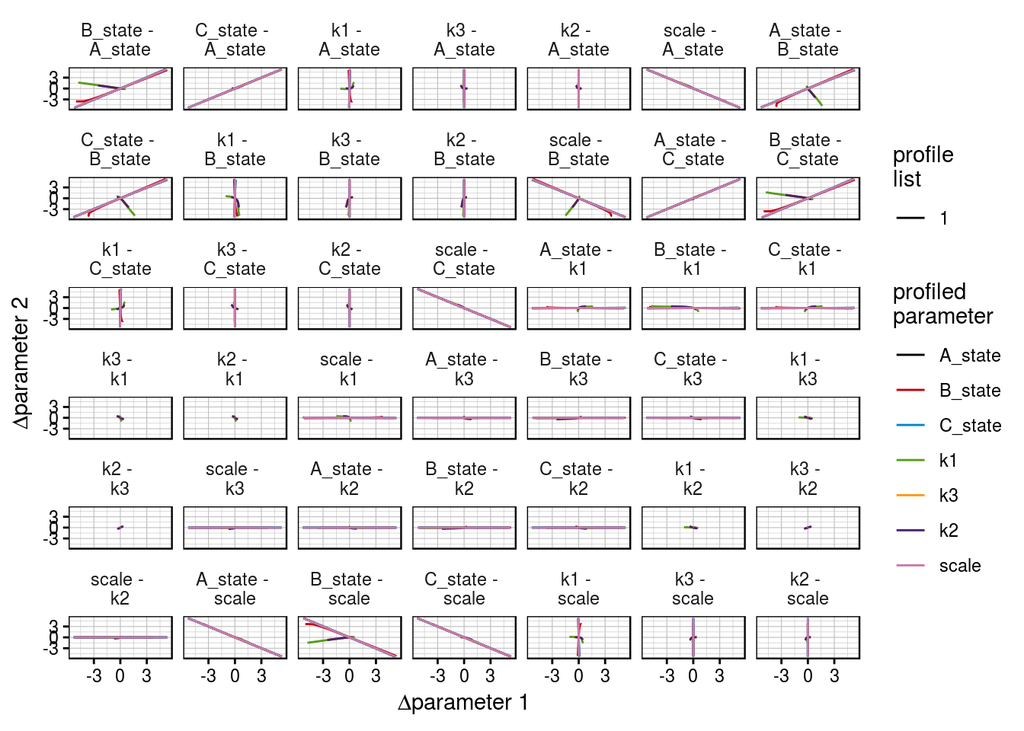

```r
plotPaths(myprofiles)
```

In order to analyze only dependencies of a specific parameter, this parameter can be defined in *whichPar*:

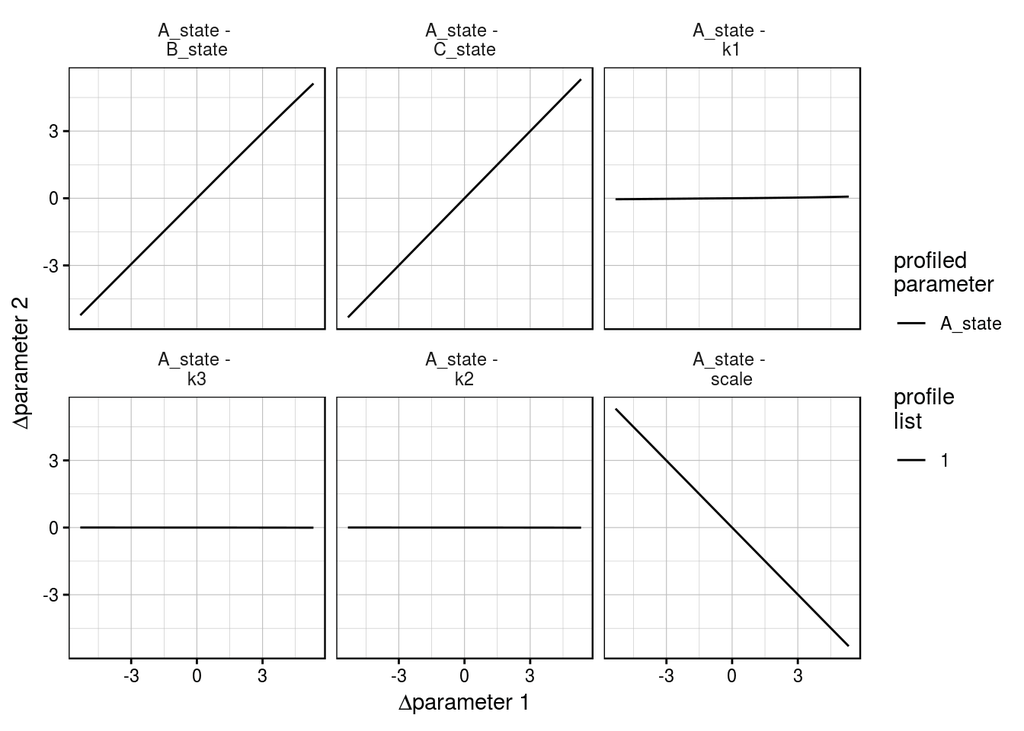

```r
plotPaths(myprofiles, whichPar = "A_state")
```